# Stanを使った変数選択

Y.Nakahashi

2018-04-20

### 背景

Stanを使ってモデリングをしている時に不満を感じる点として、変数選択が難しいということが挙げられます。もともと私自身は、例えばStepwiseやLassoなどを用いた“機械的な”変数選択があまり好きではない[^1]のですが、それでも分析を効率的に進める上でそれらの手法に頼りたくなることがあります。

そういったときに*glm*を用いているのであれば*step*関数により容易に変数選択が可能なのですが、Stanではそうもいきません。何か良い方法はないかと探していたところ、[StanのGithubレポジトリ](https://github.com/stan-dev)に`{projpred}`というそれっぽいlibraryを見つけたので、紹介がてら変数の選択精度を実験してみます[^2]。

### データ準備

#### ライブラリの読み込み

今回の分析では`{rstan}`の代わりに`{rstanarm}`というlibraryを使用します。`{rstanarm}`はRの*glm*と同じようなシンタックスのままでモデルをベイズ化することが可能で、例えば`{rstanarm}`のvignetteでは以下のようなスニペットが紹介されています(一部改変あり)[^3]。

```r
womensrole_bglm_1
```

```
stan_glm
 family:       binomial [logit]
 formula:      cbind(agree, disagree) ~ education + gender
 observations: 42
 predictors:   3
------
             Median MAD_SD
(Intercept)   2.5    0.2
education    -0.3    0.0
genderFemale  0.0    0.1

Sample avg. posterior predictive distribution of y:
         Median MAD_SD
mean_PPD 24.3    0.8

------
For info on the priors used see help('prior_summary.stanreg').
```

数字の意味は一旦置いておきますが、今回はこちらのlibraryを使用しながら進めていきます。 続いて他のlibraryを読み込みます。この辺りはvignetteそのままです。

```r
library(projpred)
library(ggplot2)
library(bayesplot)
theme_set(theme_bw())
options(mc.cores = parallel::detectCores())
```

#### シミュレーションデータの作成

実験を進めるにあたりシミュレーションデータを作成します。もちろんlibraryに付属のデータセットを使っても良いのですが、そのまま同じことをするのも面白くないので以下のように複数のデータを作成して結果を比較してみましょう：

1. 説明変数の数が少なく(20)、連続変数のみ
2. 説明変数の数が多く(100)、連続変数のみ
3. 説明変数の数が少なく(20)、ダミー変数を含む
4. 説明変数の数が多く(100)、ダミー変数を含む

見てわかる通りで、説明変数の数とダミー変数の有無によって4パターンを用意します。なぜこのパターンにしたかというと、単純にvignetteを見ていて連続変数ばかりだなと思ったのと、サンプルデータの説明変数の数が20ぐらいで、これなら機械的な選択に頼らなくても自力でどうにかできそうだな、と思ったためです。

各パターンについて特にひねりもなくデータを作成します。なお真のモデルは1と2、3と4で同一のものとしました。したがって2と4の状況は、1と3それぞれに比べて「不要なデータのみが追加された状態」での変数選択という状況になります。

以下のように各パラメータを設定します。

```r
set.seed(1)
N    <- 100 # number of observations
xn_1 <- 20  # number of variables for pattern 1
xn_2 <- 100 # number of variables for pattern 2
b1 <- 0.5 # regression coefficient of X[, 1]
b2 <- 0.8 # regression coefficient of X[, 2]
var_e <- 1 # residual variance
```

パターン1 & 2について、まず乱数によりXを生成し、そのうちの2列を使ってYを作成します。またその2列を含む20列および全列を各パターンの説明変数とします。

```r
X <- matrix(rnorm(N * xn_2, 0, 1), nrow = N, ncol = xn_2)
Y <- 1.0 + X[, 1] * b1 + X[, 2] * b2 + rnorm(N, 0, var_e)
X1 <- X[, 1:xn_1]
X2 <- X[, 1:xn_2]
dat1 <- data.frame("Y" = Y, "X" = I(X1))
dat2 <- data.frame("Y" = Y, "X" = I(X2))
```

データセットを作成する際にX1を*I*で囲って渡すことでX1全体を“X”として再定義できます。すると以下のようなformulaが実行可能になります。

```r
lm(Y ~ X, dat1)
```

```
Call:
lm(formula = Y ~ X, data = dat1)

Coefficients:
(Intercept)           X1           X2           X3           X4           X5           X6
   1.038393     0.422365     0.824111     0.006940    -0.064897     0.060024    -0.004623
         X7           X8           X9          X10          X11          X12          X13
  -0.096471     0.040521     0.123807    -0.051311     0.125116     0.009435     0.014924
        X14          X15          X16          X17          X18          X19          X20
   0.065920    -0.037135    -0.110772    -0.015537    -0.003969    -0.136834     0.095512
```

もちろんそのまま渡して`.`で指定するのでも構いません。

```r
lm(Y ~ ., tmp)
```

```
Call:
lm(formula = Y ~ ., data = tmp)

Coefficients:
(Intercept)          X.1          X.2          X.3          X.4          X.5          X.6
   1.038393     0.422365     0.824111     0.006940    -0.064897     0.060024    -0.004623
        X.7          X.8          X.9         X.10         X.11         X.12         X.13
  -0.096471     0.040521     0.123807    -0.051311     0.125116     0.009435     0.014924
       X.14         X.15         X.16         X.17         X.18         X.19         X.20
   0.065920    -0.037135    -0.110772    -0.015537    -0.003969    -0.136834     0.095512
```

続いてパターン3 & 4についても基本的に同じ流れでデータを作成しますが、一部にダミー変数を含めます。

```r
Z <- matrix(rnorm(N * xn_2, 0, 1), nrow = N, ncol = xn_2)
Z[, seq(1, 100, 10)] <- if_else(Z[, seq(1, 100, 10)] > 0, 1, 0)
Y <- 1.0 + Z[, 1] * b1 + Z[, 2] * b2 + rnorm(N, 0, var_e)
X3 <- Z[, 1:xn_1]
X4 <- Z[, 1:xn_2]
dat3 <- data.frame("Y" = Y, "X" = I(X3))
dat4 <- data.frame("Y" = Y, "X" = I(X4))
```

### フィッティング

#### stan_glmによるフィッティング

では、これらのデータを用いてフィッティングをしてみましょう。スクリプトは以下のようになります：

```r
n <- N
D <- xn_1
p0 <- 5 # prior guess for the number of relevant variables
# scale for tau (notice that stan_glm will automatically scale this by sigma)
tau0 <- p0 / (D-p0) * 1/sqrt(n)
prior_coeff <- hs(global_scale = tau0, slab_scale = 1) # regularized horseshoe prior
fit1 <- stan_glm(Y ~ X, family = gaussian(), data = dat1, prior = prior_coeff,
                seed = 777, chains = 4, iter = 2000)
```

[output not shown]

[output cut: 44 more lines]

[output not shown]

```r
D <- xn_2
p0 <- 5
tau0 <- p0/(D-p0) * 1/sqrt(n)
prior_coeff <- hs(global_scale = tau0, slab_scale = 1)
fit2 <- stan_glm(Y ~ X, family = gaussian(), data = dat2, prior = prior_coeff,
                seed = 777, chains = 4, iter = 2000)
```

[output not shown]

[output cut: 44 more lines]

[output not shown]

```r
D <- xn_1
p0 <- 5
tau0 <- p0 / (D-p0) * 1/sqrt(n)
prior_coeff <- hs(global_scale = tau0, slab_scale = 1)
fit3 <- stan_glm(Y ~ X, family = gaussian(), data = dat3, prior = prior_coeff,
                seed = 777, chains = 4, iter = 2000)
```

[output not shown]

[output cut: 44 more lines]

[output not shown]

```r
D <- xn_2
p0 <- 5
tau0 <- p0 / (D-p0) * 1/sqrt(n)
prior_coeff <- hs(global_scale = tau0, slab_scale = 1)
fit4 <- stan_glm(Y ~ X, family = gaussian(), data = dat4, prior = prior_coeff,
                seed = 777, chains = 4, iter = 2000)
```

[output not shown]

[output cut: 44 more lines]

[output not shown]

### 結果の確認

無事にフィッティングが終わったのでまずは結果を確認しましょう。`fit1`オブジェクトには多くの情報が格納されていますが、以下のようにパラメータの分布を確認します。

```r
fit1$stan_summary
```

```
                       mean      se_mean         sd          2.5%           10%
(Intercept)    1.026278e+00 0.0012818960 0.08107422    0.87096060    0.92283578
X1             3.908290e-01 0.0016254360 0.09798225    0.19341915    0.26638997
X2             8.240328e-01 0.0013608445 0.08516982    0.65884688    0.71552972
X3            -1.059357e-03 0.0005388889 0.03408233   -0.08025937   -0.03484370
X4            -1.872770e-02 0.0007089570 0.04483838   -0.13979248   -0.07768171
X5             2.138502e-02 0.0006738661 0.04261903   -0.03511247   -0.01201396
X6             2.839625e-04 0.0005962887 0.03771261   -0.08488007   -0.03459415
X7            -1.479365e-02 0.0006131310 0.03877781   -0.12128749   -0.06505112
X8             8.204673e-03 0.0005430000 0.03434234   -0.05332885   -0.02197466
X9             1.264384e-02 0.0006168079 0.03901036   -0.05000321   -0.01892019
X10           -4.923477e-03 0.0005510948 0.03485430   -0.08733749   -0.04414636
X11            2.316991e-02 0.0007605818 0.04810342   -0.03878082   -0.01400559
X12           -1.698669e-03 0.0005194107 0.03285042   -0.07946051   -0.03634699
X13            2.263554e-03 0.0005161903 0.03264674   -0.06498154   -0.02807651
X14            1.566383e-02 0.0007428033 0.04697900   -0.05304627   -0.02074214
X15           -3.651269e-03 0.0005417556 0.03426364   -0.08640817   -0.04298903
X16           -2.766223e-02 0.0007915916 0.05006465   -0.16238952   -0.09806754
X17           -4.862046e-03 0.0005765959 0.03646713   -0.09287803   -0.04465329
X18           -1.166919e-02 0.0005625135 0.03557648   -0.10683107   -0.05586242
X19           -2.867247e-02 0.0008141944 0.05149418   -0.16955957   -0.10197630
X20            3.659613e-02 0.0009127823 0.05772942   -0.03281041   -0.01032980
sigma          7.940359e-01 0.0009464170 0.05985666    0.68747029    0.72083992
mean_PPD       1.032079e+00 0.0017321715 0.10955215    0.81915879    0.89242867
log-posterior -2.385133e+02 0.1946768625 6.71202017 -252.85915358 -247.58454746
                        25%           50%           75%           90%         97.5%
(Intercept)    9.695387e-01  1.025776e+00  1.083455e+00    1.12962235    1.18570039
X1             3.278100e-01  3.940279e-01  4.542220e-01    0.51236797    0.57793402
X2             7.672683e-01  8.238806e-01  8.816342e-01    0.93310548    0.98857084
X3            -1.106505e-02 -1.177711e-04  1.032889e-02    0.03180827    0.07368474
X4            -3.228712e-02 -3.977780e-03  3.213492e-03    0.01638515    0.04656703
X5            -1.858049e-03  6.263328e-03  3.500771e-02    0.07857940    0.13847975
X6            -1.007021e-02 -1.416090e-05  1.027719e-02    0.03667715    0.08528484
X7            -2.570777e-02 -3.446167e-03  3.694061e-03    0.01699010    0.04314272
X8            -5.590128e-03  1.169800e-03  1.713618e-02    0.04847371    0.09830802
X9            -3.782982e-03  2.757998e-03  2.176391e-02    0.06156243    0.12166660
X10           -1.441876e-02 -7.613838e-04  7.210478e-03    0.02684685    0.06332622
X11           -1.891200e-03  6.502697e-03  3.649778e-02    0.08871649    0.15693107
X12           -1.100874e-02 -1.829689e-04  9.340298e-03    0.02950046    0.06902596
X13           -8.165926e-03  2.367888e-04  1.171325e-02    0.03457824    0.08280748
```

[output cut: 20 more lines]

```
X9            4000.000 0.9995490
X10           4000.000 0.9998431
X11           4000.000 1.0011725
X12           4000.000 0.9998937
X13           4000.000 0.9996546
X14           4000.000 1.0002031
X15           4000.000 0.9996101
X16           4000.000 0.9998289
X17           4000.000 1.0000861
X18           4000.000 0.9994776
X19           4000.000 0.9997480
X20           4000.000 0.9994397
sigma         4000.000 0.9997257
mean_PPD      4000.000 1.0000951
log-posterior 1188.715 1.0049925
```

この結果を見るとX1とX2で設定通りの値が得られているようですね。

```r
sel1$varsel$vind # variables ordered as they enter during the search
```

```
 X2  X1 X20 X16 X19 X11  X5 X14 X18  X4  X7  X9  X8 X17 X10 X15 X13 X12  X3  X6
  2   1  20  16  19  11   5  14  18   4   7   9   8  17  10  15  13  12   3   6
```

> The loo method for stanreg objects provides an interface to the loo package for approximate leaveone-out cross-validation (LOO). The LOO Information Criterion (LOOIC) has the same purpose as the Akaike Information Criterion (AIC) that is used by frequentists. Both are intended to estimate the expected log predictive density (ELPD) for a new dataset.

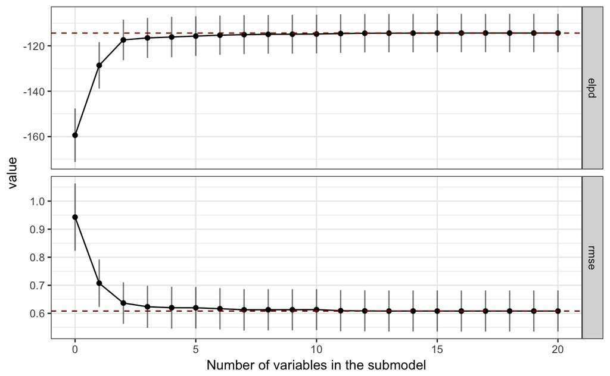

各パラメータの分布についても見てみましょう。上位5個に選ばれた説明変数に限定してプロットしてみます。

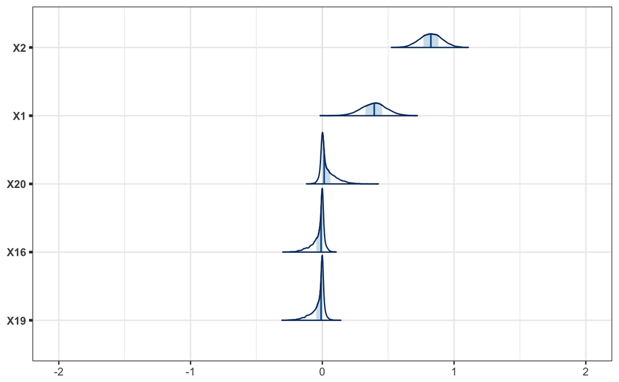

効果のなかった変数は0を中心に集中して分布していることがわかります。

残りの各パターンについても同様に見ていきますが、個別に確認するのは面倒なので一度にまとめてしまします。

```r
sel2$varsel$vind
```

```
 X2  X1 X87 X24 X83 X71 X89 X18 X95 X85  X4 X67 X19 X16 X60 X56 X55 X53 X42 X20
  2   1  87  24  83  71  89  18  95  85   4  67  19  16  60  56  55  53  42  20
```

```r
sel3$varsel$vind
```

```
 X2 X14  X4  X1 X18  X5 X16  X3  X9 X15 X19 X20  X6  X8 X17 X11  X7 X12 X13 X10
  2  14   4   1  18   5  16   3   9  15  19  20   6   8  17  11   7  12  13  10
```

```r
sel4$varsel$vind
```

```
 X2 X90 X74 X45 X64 X14 X25 X52 X60  X4 X20 X16 X22  X1 X63 X41  X9 X26 X53  X5
  2  90  74  45  64  14  25  52  60   4  20  16  22   1  63  41   9  26  53   5
```

むむ。。。

いずれのパターンでも2列目はちゃんと選ばれていますが、パターン3と4では1列目が選ばれていませんね。 プロットも見てみましょう。

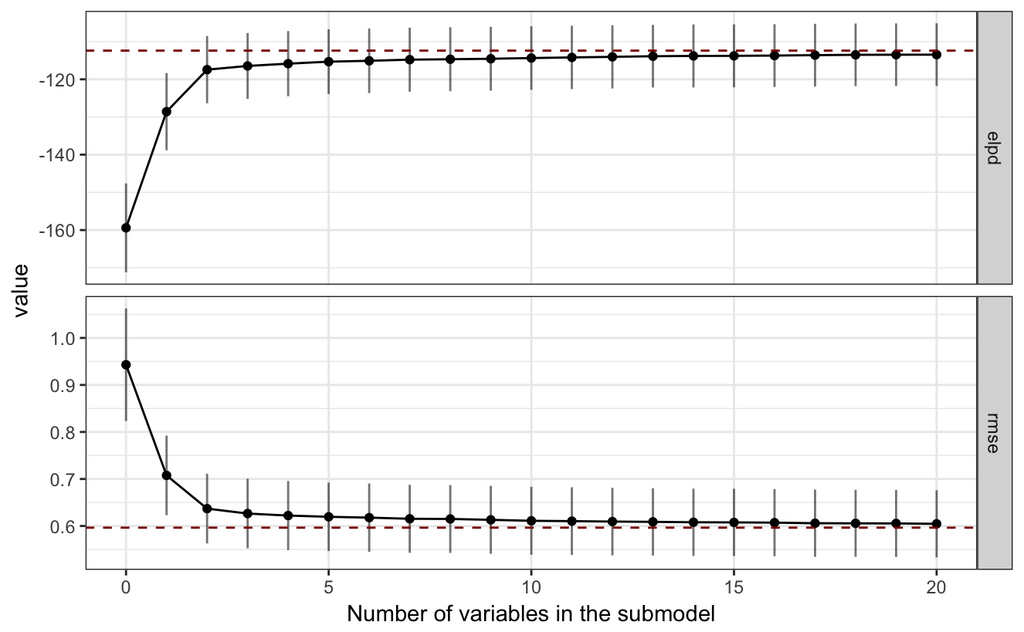

```r
# png("../Image/projpred_sel2_varsel.png")
varsel_plot(sel2, stats=c('elpd', 'rmse'))
```

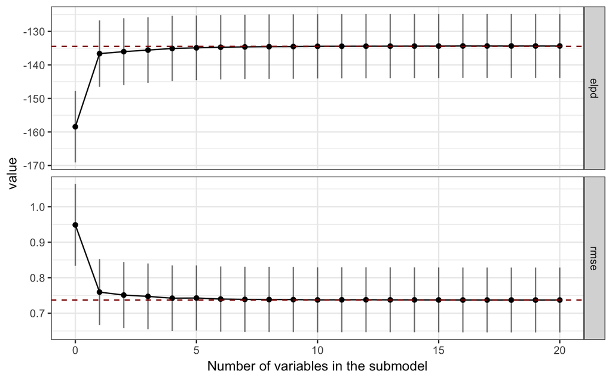

```r
# dev.off()
# png("../Image/projpred_sel3_varsel.png")
varsel_plot(sel3, stats=c('elpd', 'rmse'))
```

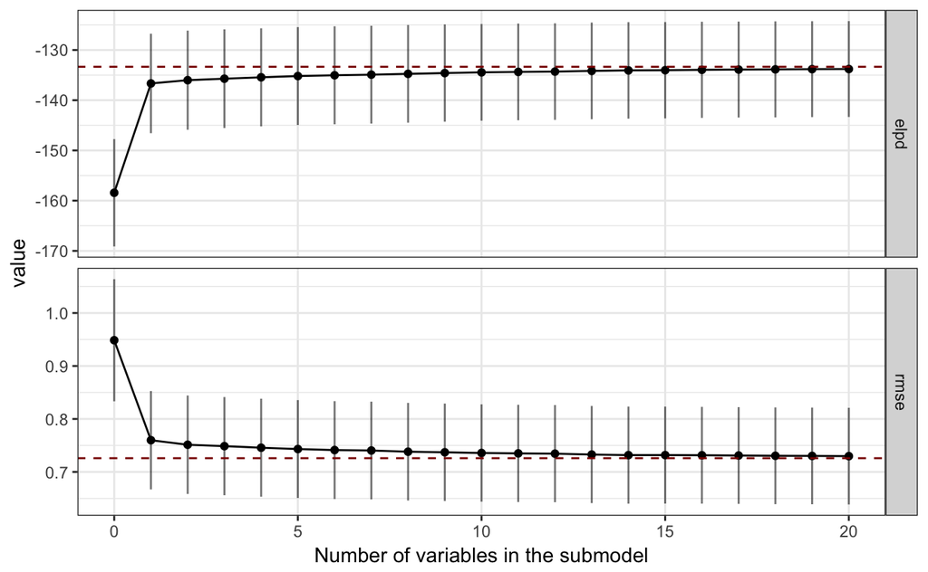

```r
# dev.off()
# png("../Image/projpred_sel4_varsel.png")
varsel_plot(sel4, stats=c('elpd', 'rmse'))
```

```r
# dev.off()
```

まぁ選ばれていないので当然ですが、2変数目ですでにフルモデルにおけるelpdやrmseと接するようになっており、モデルの精度改善に貢献しているのは1変数目だけという結果になっています。

パラメータの分布を見ても、パターン1と比較するといずれも分布の裾が広くなっています。さらにパターン3では正の効果を受けたためか右に裾を引く形とはなっているものの、効果のない他の変数とほとんど変わらない分布となってしまいました。ダミー変数は推定が難しいようです。

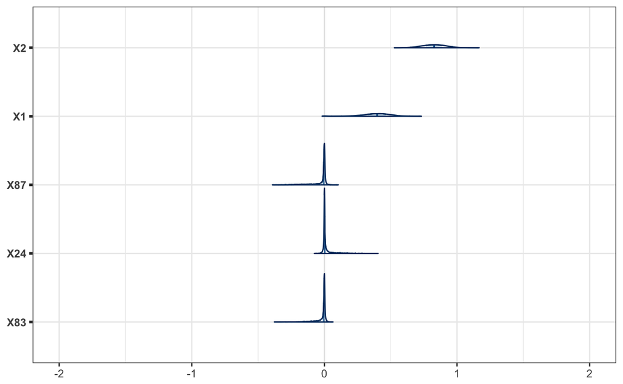

```r
# png("../Image/projpred_sel2_mcmcarea.png")
mcmc_areas(as.matrix(sel2),
           pars = names(sel2$varsel$vind[1:5])) +
   coord_cartesian(xlim = c(-2, 2))
```

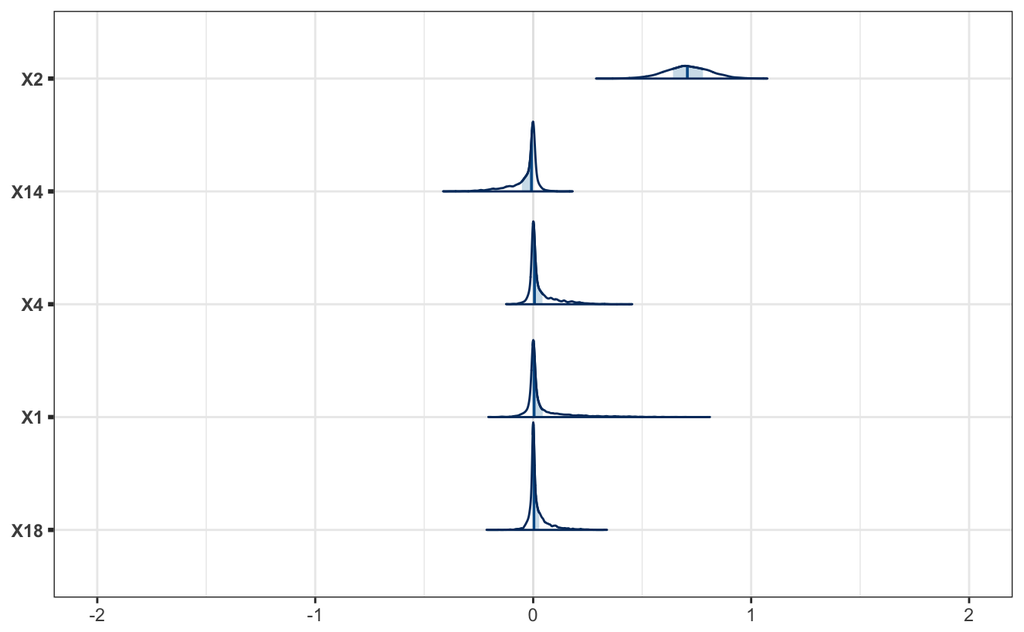

```r
# dev.off()
# png("../Image/projpred_sel3_mcmcarea.png")
mcmc_areas(as.matrix(sel3),
           pars = names(sel3$varsel$vind[1:5])) +
   coord_cartesian(xlim = c(-2, 2))
```

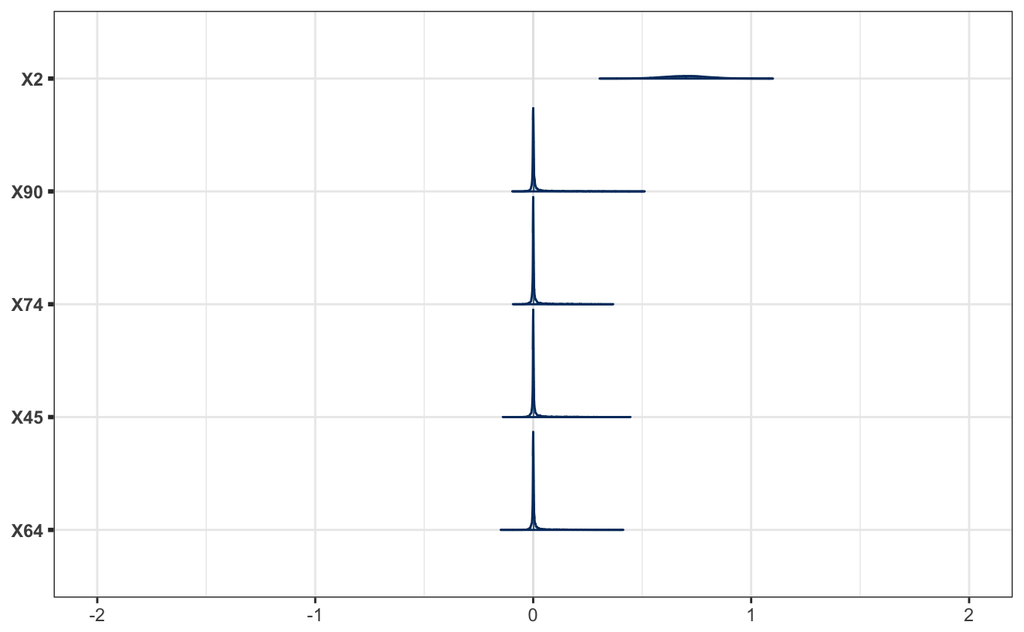

```r
# dev.off()
# png("../Image/projpred_sel4_mcmcarea.png")
mcmc_areas(as.matrix(sel4),
           pars = names(sel4$varsel$vind[1:5])) +
   coord_cartesian(xlim = c(-2, 2))
```

```r
# dev.off()
```

#### 追試

では、ダミー変数が含まれる場合に真のパラメータを捉えることができる確率としてはどの程度になるのでしょうか。パターン3を100回繰り返し、そのうち何回真の変数セットを選択できるか確認してみましょう。

```
       [,1] [,2]
  [1,] "x2" "x10"
  [2,] "x2" "x1"
  [3,] "x2" "x1"
  [4,] "x2" "x19"
  [5,] "x2" "x4"
  [6,] "x2" "x17"
  [7,] "x2" "x1"
  [8,] "x2" "x11"
  [9,] "x2" "x1"
 [10,] "x2" "x4"
 [11,] "x2" "x1"
 [12,] "x2" "x1"
 [13,] "x2" "x1"
 [14,] "x2" "x1"
```

[output cut: 86 more lines]

```r
table(out[, 1])
```

```
 x2
100
```

```r
table(out[, 2])
```

```
 x1 x10 x11 x12 x13 x14 x15 x17 x18 x19 x20  x3  x4  x5  x6  x7  x9
 55   2   2   3   3   1   1   5   5   1   1   2   7   4   1   4   3
```

上記の通り、連続変数である2列目の選択確率は100%である一方、ダミー変数である1列目は約半数しか選択されないという結果になりました。もちろん回帰係数の大小にも影響されるのでしょうが、結構衝撃的な結果に思えます。

### 終わりに

これまでの実験の結果をまとめると以下のようになりそうです：

- 連続変数であれば説明変数を20から100に増やしても大きな問題なく変数を選択できそう
- ダミー変数の変数選択は難しく、今回の条件の場合、半分の確率で失敗する
- ダミー変数はパラメータの推定も難しい

実際のデータ分析の現場では真のパラメータを予め知ることができないため、変数選択の結果を受け入れざるを得ないことがあるかと思います。しかし今回の実験の結果からは「真の変数セットを選択できる確率は半分程度しかない」ことが示されており、機械的な変数の取捨選択がどれほど危険であるかを教えてくれているのではないでしょうか。

とは言え今回実験に使用した`{projpred}`は便利なlibraryであると思いますので、これから活用しつつも引き続き変数選択の方法について探していこうと思います。

[^1]: 探索的な分析の時はともかく、変数の機械的な取捨選択は「モデリングじゃない！」という気分になってしまいます
[^2]: 他にも良い手法はあると思います。例えば松浦さんのアヒル本では、回帰係数の事前分布を二重指数分布とすることで不要な説明変数を削る“Bayesian Lasso”という手法が紹介されています
[^3]: Gelmanのarm::bayesglmとの関係はよくわかりません。一応、dependencyではないようですが。